# Examen_Parcial

Brenda_Silvestre

24/7/2021

## Parte 1

**1. Se tiene una variable x (no necesariamente temperatura) que depende de la elevacion. Se sabe que entren los 1000 y 3000 metros, esta variable se ve reducido en 2 unidades cada 500 metros. Entre los 3000 y 4000 metros, varia en 0.5 unidades, y a una altitud mayor, su valor es constante. Cree una funcion que permita obtener el valor de esta variable, unicamente con el dato de la elevacion.**

**El valor de la variable x a 1000 metros es de 81.4 unidades**

```r
data <- function(x){
  if (x>=1000 & x<=3000){
    t<-85.4 -(2*(x/500))
  }
  if(x>3000 & x<=4000){
    t<-85.4 -(0.5*(x/500))
}
  if(x>4000){
    t<-85.4
}
  return(t)
}
data(2500)
```

```
## [1] 75.4
```

**2. Resolver el siguiente sistema de ecuaciones.** $3a + 2b - 2c = 0\\2a - 1b + 3c = 9\\a + 4b + 2c = -4$

```r
A =matrix(c(3,2,1,2,-1,4,-2,3,2), ncol=3,nrow=3)
A
```

```
##      [,1] [,2] [,3]
## [1,]    3    2   -2
## [2,]    2   -1    3
## [3,]    1    4    2
```

```r
L <-c(0,9,-4)
solve(A,L)
```

```
## [1]  2 -2  1
```

## Parte 2

**A partir del siguiente conjunto de datos, se describen las variables:** $uh name-> Nombre de cuenca\\bh esc -> Escenario (observado y modelos climaticos)\\bh month -> Meses\\bh pc -> Precipitacion\\bh er -> Evapotranspiracion Real\\bh rh -> Rendimiento Hidrico\\bh qd -> Caudal$

```r
setwd("C:/Users/Brenda Silvestre/Documents/programR")
tabla <- read.csv("mods_clima_uh.csv")
library("tidyverse")
tabla2 <- as_tibble(tabla)
tabla2
```

```
## # A tibble: 8,064 x 8
##     code uh_name       bh_esc    bh_month   bh_pc  bh_er bh_rh bh_qd
##    <int> <chr>         <chr>        <int>   <dbl>  <dbl> <dbl> <dbl>
##  1  1394 Cuenca Tumbes Observado        1 108.    31.5    34.7  62.1
##  2  1394 Cuenca Tumbes Observado        2 182.    50.8    66.0 138.
##  3  1394 Cuenca Tumbes Observado        3 228.    79.1    98.2 190.
##  4  1394 Cuenca Tumbes Observado        4 199.    66.5   112.  225.
##  5  1394 Cuenca Tumbes Observado        5  39.0   23.5    74.6 157.
##  6  1394 Cuenca Tumbes Observado        6   8.39   7.10   46.1 102.
##  7  1394 Cuenca Tumbes Observado        7   1.11   1.89   33.3  69.6
##  8  1394 Cuenca Tumbes Observado        8   0.621  0.927  23.7  48.1
##  9  1394 Cuenca Tumbes Observado        9   2.07   2.10   16.6  33.8
## 10  1394 Cuenca Tumbes Observado       10  13.4   10.5    13.4  25.3
## # ... with 8,054 more rows
```

**(a) Calcular la precipitacion acumulada anual (Valores observados) para la cuenca asignada.**

```r
#Para cuenca Tumbes
#Observado
tabla2 <- as_tibble(tabla) #convertimos a tibble
obs <- tabla2 %>%
    subset( uh_name == "Cuenca Tumbes" & bh_esc == "Observado" ) %>% #filtramos por cuenca y observado
    group_by(uh_name) %>% #agrupamos por nombre solo Tumbes
    summarize( pp_acum = sum(bh_pc))
obs
```

```
## # A tibble: 1 x 2
##   uh_name       pp_acum
##   <chr>           <dbl>
## 1 Cuenca Tumbes    852.
```

```r
#ACCESS
ACCESS <- tabla2 %>%
  subset( uh_name == "Cuenca Tumbes" & bh_esc == "ACCESS 1.0" ) %>%
  group_by(uh_name) %>%
  summarize(pp_acum = sum(bh_pc))
ACCESS
```

```
## # A tibble: 1 x 2
##   uh_name       pp_acum
##   <chr>           <dbl>
## 1 Cuenca Tumbes   1073.
```

```r
#MPI
MPI <- tabla2 %>%
  subset( uh_name == "Cuenca Tumbes" & bh_esc == "MPI-ESM-LR" ) %>%
  group_by(uh_name) %>%
  summarize(pp_acum = sum(bh_pc))
MPI
```

```
## # A tibble: 1 x 2
##   uh_name       pp_acum
##   <chr>           <dbl>
## 1 Cuenca Tumbes    839.
```

```r
#HagHEM2
HAD <- tabla2 %>%
  subset( uh_name == "Cuenca Tumbes" & bh_esc == "HadGEM2-ES" ) %>%
  group_by(uh_name) %>%
  summarize(pp_acum = sum(bh_pc))
HAD
```

```
## # A tibble: 1 x 2
##   uh_name       pp_acum
##   <chr>           <dbl>
## 1 Cuenca Tumbes    969.
```

**(b) Calcular el porcentaje de sesgo (%, PBIAS) de los escenarios climaticos (ACCESS, HADGEM2, MPI) respecto a los datos observados para cada mes (enero - diciembre) de cada variable, para la cuenca asignada.**

```r
#Sigo trabajando con cuenca Tumbes
#no entiendo profe :C
```

**(c) De la pregunta anterior, ¿Cual es el escenario climatico mas preciso?**

**(d) Graficar, con ggplot2, la precipitacion (enero a diciembre) observada y modelos climaticos.**

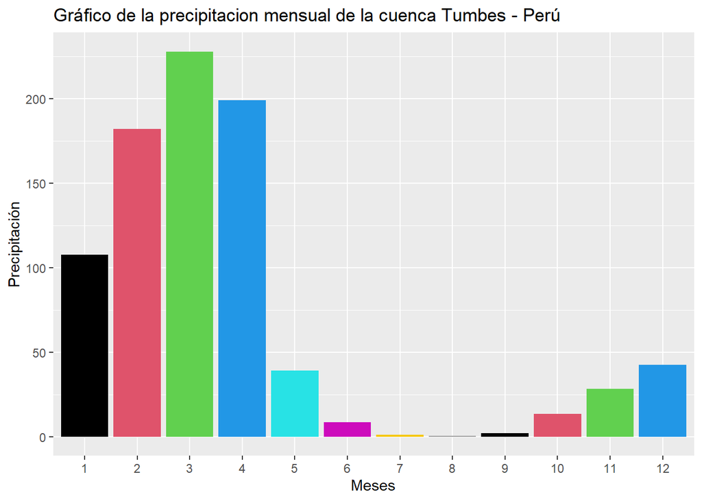

```r
pp <-tabla2$bh_pc[1:12]
mes <-tabla2$bh_month[1:12]
mes2 <- as.factor(mes)
tabla3 <- data.frame(mes2,pp)

ggplot(data=tabla3, aes(x=mes2, y=pp)) +
  geom_bar(stat="identity", fill=mes2)+
  labs (title= "Gráfico de la precipitacion mensual de la cuenca Tumbes - Perú",
        x="Meses",
        y="Precipitación"
  )
```

## Parte 3

**1. Se tiene el conjunto de datos de temperatura diaria (periodo 1928 - 2015) de ciertas estaciones meteorol logicas (temperatureDataset.csv), donde cada una de estas estan asociadas a un codigo unico (p.e. qc00000208). Si existen valores iguales a -99.9, considerarlos como missing values y convertirlos a NA.** $Grupo 01 [A-B] -> qc00000441\\Grupo 02 [C-D] -> qc00000435\\Grupo 03 [E-F] -> qc00000765\\Grupo 04 [G-H] -> qc00000755\\Grupo 05 [I-J] -> qc00000749\\Grupo 06 [K-L]-> qc00000837\\Grupo 07 [M-N] -> qc00000830\\Grupo 08 [O-P] -> qc00000746\\Grupo 09 [R-S] -> qc00000804\\Grupo 10 [T-Z] -> qc00000805$

```r
setwd("C:/Users/Brenda Silvestre/Documents/programR")
temp <- read.csv("temperatureDataset.csv")
view(temp)
head(temp)
```

```
##        DATE qc00000441 qc00000435 qc00000765 qc00000755 qc00000749 qc00000837
## 1 2/11/1928      -99.9      -99.9      -99.9      -99.9      -99.9      -99.9
## 2 3/11/1928      -99.9      -99.9      -99.9      -99.9      -99.9      -99.9
## 3 4/11/1928      -99.9      -99.9      -99.9      -99.9      -99.9      -99.9
## 4 5/11/1928      -99.9      -99.9      -99.9      -99.9      -99.9      -99.9
## 5 6/11/1928      -99.9      -99.9      -99.9      -99.9      -99.9      -99.9
## 6 7/11/1928      -99.9      -99.9      -99.9      -99.9      -99.9      -99.9
##   qc00000830 qc00000746 qc00000804 qc00000805
## 1      -99.9      -99.9      -99.9      -99.9
## 2      -99.9      -99.9      -99.9      -99.9
## 3      -99.9      -99.9      -99.9      -99.9
## 4      -99.9      -99.9      -99.9      -99.9
## 5      -99.9      -99.9      -99.9      -99.9
## 6      -99.9      -99.9      -99.9      -99.9
```

```r
fecha <- temp$DATE
est <- temp$qc00000804

tempA <- seq(
  as.Date("1/09/1983"),
  as.Date("30/08/1984"),
  by="day"
)
```